# Visualisering af antal talte ord med brug af en fast farvepalette

# Find farver

```r
skuespil_titler <- plays %>% select(title) %>% distinct(title) %>% pull(title)
```

Hvor mange skuespil?

```r
skuespil_titler %>% length()
```

```
[1] 35
```

```r
skuespil_farver <- qualitative_hcl(35, palette = "Dynamic")
```

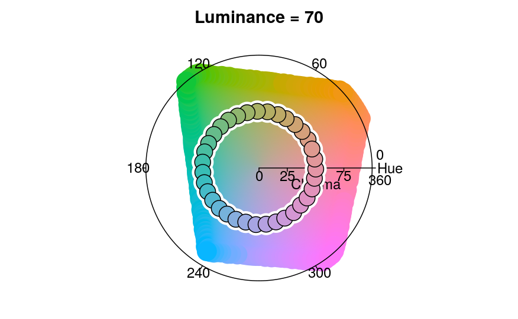

```r
hclplot(skuespil_farver)
```

Aha, en cirkel — det ved jeg ikke nok om til at kunne kommenterer det…

Vi kan nu lave en liste af par af skuespil titel og skuespil farve

```r
names(skuespil_farver) <- skuespil_titler
```

Lad os se det første par

```r
skuespil_farver[1]
```

```
Husspøgelse
  "#DB9D85"
```

# Implementation af `character_plot` med faste farver

```r
character_plot_with_color <- function(character_name, skuespil_farver, skuespil) {
  skuespil %>%
  filter(speaker == character_name) %>%
  arrange(year) %>%
  ggplot(aes(fill = title, y = freq, x = title)) +
    geom_bar(stat="identity") +
    theme(legend.position="bottom") +
    labs(
      title = "Procent talte ord over år og komedier",
      subtitle = toupper(character_name),
      caption = "Kilde: DSL"
    ) +
    scale_fill_manual(values = skuespil_farver) +
    scale_y_continuous(limits = c(0,0.4), breaks = c(0,0.1,0.2,0.3,0.4)) +
    xlab("year") +
    ylab("Procent sagte ord") +
    facet_wrap(~year, ncol=nrow(skuespil), strip.position = "top") +
    theme(axis.text.x=element_blank())
}
```

Sagens kerne er linien `scale_fill_manual(values = skuespil_farver) +`. Denne teknik kan benyttes i alle andre plot, hvor der anvendes farve.

# Visualiser

Som et eksempel, viser jeg har hvor mange ord henholdsvis Leonora og Pernille siger, hvor skuespillenes farver meget gerne skulle kunne sammenlignes på tværs af graferne.

Først Leonora:

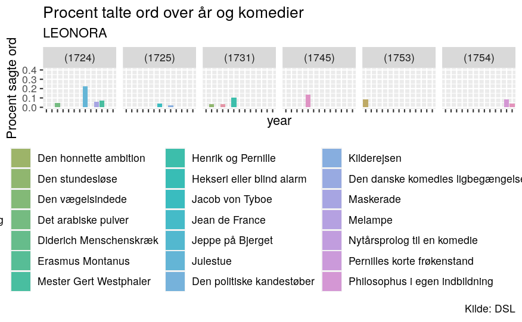

```r
character_plot_with_color ("leonora", skuespil_farver, summary)
```

Så Pernille:

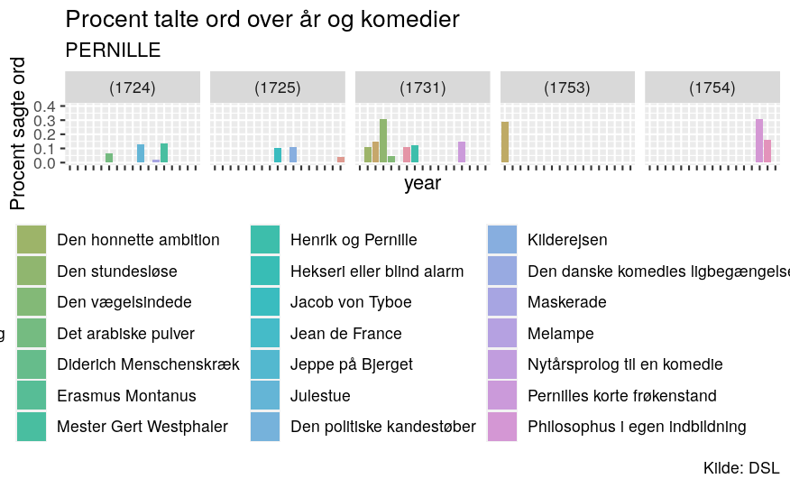

```r
character_plot_with_color ("pernille", skuespil_farver, summary)
```

[^1]: HCL står for hue, chroma og luminance. Se mere på [HCL colorspace](https://en.wikipedia.org/wiki/HCL_color_space)